# C07 — Kategorie i zachowanie: tabela, chi-kwadrat i Monte Carlo

Zarządzanie informacją — ćwiczenie i zadanie Z07 — 2026/27

2026/27

# Początek pracy na ćwiczeniu C07

Otwórz swój projekt kursu w Posit Cloud albo RStudio na własnym komputerze; pakiet kursu `badaniaZI` jest w nim zainstalowany. Dwa polecenia z następnego bloku wpisujesz w konsoli RStudio, czyli w dolnym panelu ze znakiem `>`; w miejsce `TWOJE_ID` wpisz swoje ID, a w miejsce `Imię Nazwisko` — swoje imię i nazwisko. Dokument PDF zawiera dwa polecenia jako tekst instrukcji.

```r
library(badaniaZI)
rozpocznij_zajecia("C07", id_studenta = "TWOJE_ID", student = "Imię Nazwisko")
```

Sprawdź w komunikacie ID oraz imię i nazwisko. Przy pierwszym starcie funkcja tworzy folder `moje-badania` i zapisuje w nim oba dane; pliki pracy zachowują je także po zamknięciu projektu, a imię i nazwisko trafiają do nazwy oddawanego pliku.

Funkcja `rozpocznij_zajecia()` otwiera własny plik `zadanie.Rmd`, zapamiętuje katalog pracy i kopiuje do folderu `moje-badania/materialy` wersję HTML i PDF ćwiczenia oraz rubrykę zadania. Pracuj w otwartym pliku `zadanie.Rmd` do końca zajęć. Najpierw uruchom blok `przygotowanie`, a potem kolejne części LEARN i CHALLENGE. Przy problemie poproś prowadzącego o pomoc; plik pracy i własne ID pozostają bez zmian.

Pierwszy chunk, `przygotowanie`, wczytuje gotowy skrypt `analiza.R`. Skrypt tworzy zbiór S02 po trzech regułach ćwiczenia C02 (usunięcie identycznych duplikatów, kod 99 w pozycjach ankiety jako brak, czas spoza 0–120 minut jako brak) i tabelę grupy oraz powodzenia. Funkcja pomocnicza `analiza_tabeli()` liczy oczekiwania, chi-kwadrat, test Fishera, Monte Carlo, różnicę proporcji z przedziałami i V. Skrypt zawiera też demonstracje rzadkich komórek, bootstrapu V i pomiaru przed–po, dane archiwum do części CHALLENGE oraz funkcje wyświetlające tabele i wykresy. Wszystkie dane są syntetyczne.

# Trzeci wskaźnik: czy znaleziono dokument

Biblioteka chce poprawić korzystanie z katalogu. Ćwiczenie C06 (Dwie grupy) wykazało różnicę indeksu nowi minus doświadczeni równą −0,44 punktu (p < 0,001) i różnicę czasu 0,31 minuty z przedziałem od −1,6 do 2,3 minuty. Ćwiczenie C07 pyta o wynik obserwacyjny: czy osoba znalazła wskazany dokument.

Powodzenie ma kod 1, a niepowodzenie 0. Kody 1 i 0 oznaczają dwie kategorie binarnego kryterium wykonania zadania. Kryterium sukcesu oraz traktowanie rezygnacji i problemu technicznego ustala protokół przed zbieraniem danych.

Zespół pyta: „Czy nowi równie często osiągają cel?”. Odpowiedź wymaga liczby sukcesów i liczby osób w każdej grupie; kierunek różnicy podają proporcje grup, a niepewność i test przychodzą po nich.

Grupy S02 są obserwacyjne, więc związek doświadczenia z powodzeniem opisuje współwystępowanie. Dane syntetyczne służą ćwiczeniu metody.

## Przebieg spotkania

Przeznacz około 5 minut na odtworzenie pracy, 30 minut na pięć bloków LEARN, 50 minut na pięć zadań CHALLENGE i 5 minut na zapis oraz oddanie. W LEARN uruchamiasz gotowy kod i porównujesz wynik z podaną interpretacją. W CHALLENGE piszesz własne krótkie akapity pod wynikami, poza blokiem R. Gdy odczyt wyniku sprawia trudność, pytasz prowadzącego. Rozwinięcia po części obowiązkowej służą powtórce i pozostają poza oceną.

W CHALLENGE analizujesz przygotowane dane archiwum cyfrowego; projekt indywidualny rozpoczyna się na ćwiczeniu C09 (Warsztat projektu). Po spotkaniu umiesz wyjaśnić pochodzenie każdej liczby w komórce, znaczenie oczekiwania przy niezależności i powód, dla którego V jest nieujemne. Kod wykonuje obliczenia; Twoim zadaniem jest zgodność pytania, mianownika, efektu i wniosku.

Bloki LEARN kończą się **wzorcem zapisu** — przykładowym zdaniem według standardu APA (*Publication Manual of the American Psychological Association*, 7. wydanie, 2020): symbol statystyczny kursywą, stopnie swobody i N w nawiasie, przedział w nawiasie kwadratowym, przecinek jako separator dziesiętny. Na ćwiczeniu C07 wzorce dotyczą tabeli 2 × 2: liczebności, testu chi-kwadrat, testu Monte Carlo i efektu w punktach procentowych. Zadania CHALLENGE stosują wzorce do archiwum cyfrowego.

# LEARN 1: osoby, sukcesy i mianowniki

Jednostką jest osoba ze znaną grupą i znanym wynikiem zadania. Tabela wymaga znanej grupy i znanego wyniku, więc N = 148 — o jedną osobę więcej niż w analizie indeksu (C05–C06), bo powodzenie jest znane także u osoby bez ważnego indeksu.

Zero oznacza obserwowane niepowodzenie, a brak — nieznany wynik; brak pozostaje brakiem. Regułę dla rezygnacji zapisuje protokół przed zbieraniem danych.

Tabela „Liczebności: 0 = niepowodzenie, 1 = sukces” podaje: doświadczeni — 22 niepowodzenia i 52 sukcesy, nowi — 29 niepowodzeń i 45 sukcesów. Każda grupa liczy 74 osoby, razem 148. Komórka „doświadczeni, 1” oznacza 52 osoby doświadczone, które znalazły dokument.

```r
widok <- liczebnosci_tabeli(wynik)
print(widok)
```

**Liczebności: 0 = niepowodzenie, 1 = sukces**

| Grupa | 0: niepowodzenie | 1: sukces |
| --- | --- | --- |
| doświadczeni | 22 | 52 |
| nowi | 29 | 45 |

## Marginesy podsumowują te same osoby

Sumy wierszy i kolumn to marginesy tabeli. Marginesy podsumowują te same osoby; test otrzymuje tabelę 2 × 2 bez sum. Tabela z marginesami podaje 97 sukcesów i 51 niepowodzeń; oba sposoby sumowania dają N = 148.

```r
widok <- liczebnosci_tabeli(wynik, marginesy = TRUE)
print(widok)
```

**Liczebności: 0 = niepowodzenie, 1 = sukces**

| Grupa | 0: niepowodzenie | 1: sukces | Suma |
| --- | --- | --- | --- |
| doświadczeni | 22 | 52 | 74 |
| nowi | 29 | 45 | 74 |
| Suma | 51 | 97 | 148 |

Jedna osoba wnosi dokładnie jedną komórkę. Własność odróżnia tabelę od pytania wielokrotnego wyboru z ćwiczenia C04, w którym osoba wskazywała kilka kanałów; liczenie wskazań jako osób zawyża N.

## Mianownik procentu wyraża pytanie

Skuteczność grupy opisuje proporcja sukcesów w grupie:

$$\widehat\pi_g=\frac{\text{liczba sukcesów w grupie }g}{n_g}.$$

Dla doświadczonych $52/74=0{,}7027$, czyli 70,27%; dla nowych $45/74=0{,}6081$, czyli 60,81%. Równe N ułatwia przykład; reguła obowiązuje także przy nierównych grupach.

Tabela „Odsetki w grupach [%]” podaje procenty wierszowe: każdy wiersz sumuje się do 100%.

```r
widok <- odsetki_tabeli(wynik, mianownik = "grupa")
print(widok)
```

**Odsetki w grupach [%]**

| Grupa | 0: niepowodzenie | 1: sukces |
| --- | --- | --- |
| doświadczeni | 29,73 | 70,27 |
| nowi | 39,19 | 60,81 |

Procenty kolumnowe odpowiadają na inne pytanie: jaki udział wśród wszystkich sukcesów lub niepowodzeń mają osoby z danej grupy. Tabela „Skład kategorii wyniku [%]” dzieli te same liczniki przez sumy kolumn: udział nowych wśród sukcesów wynosi 45/97 = 46,4%, a doświadczonych 52/97 = 53,6%.

```r
widok <- odsetki_tabeli(wynik, mianownik = "wynik")
print(widok)
```

**Skład kategorii wyniku [%]**

| Grupa | 0: niepowodzenie | 1: sukces |
| --- | --- | --- |
| doświadczeni | 43,14 | 53,61 |
| nowi | 56,86 | 46,39 |

Skuteczność nowych wynosi 45/74 = 60,8%; udział nowych wśród sukcesów — 45/97 = 46,4%. Procent kolumnowy opisuje skład kategorii wyniku. Mianownik należy do znaczenia wyniku.

## Wykres struktury

Wykres mozaikowy ma słupek na każdą grupę: szerokość słupka jest proporcjonalna do N grupy, a odcinki — do udziałów niepowodzenia i sukcesu. Etykiety w odcinkach podają liczbę osób i odsetek.

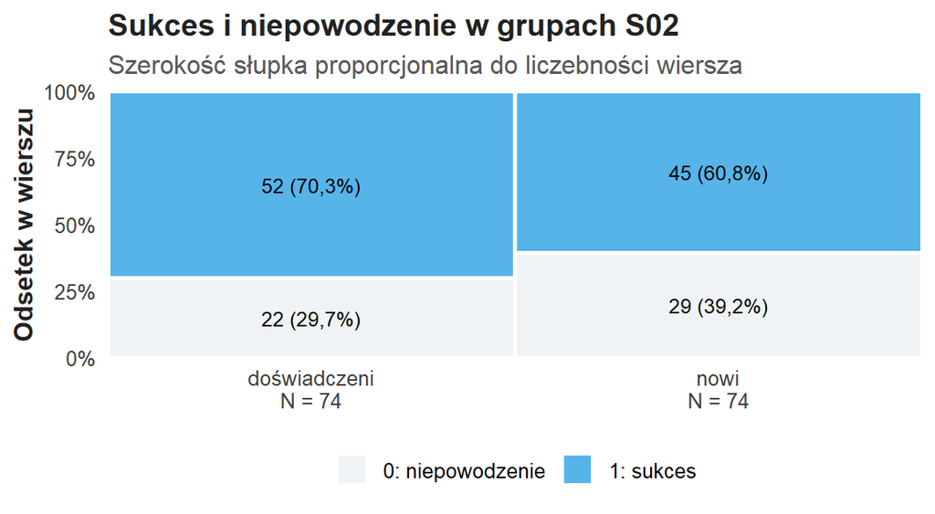

Sukces i niepowodzenie w grupach S02: wykres mozaikowy. Szerokość słupka jest proporcjonalna do N grupy — oba słupki mają tę samą szerokość (74 osoby). Oś pionowa: odsetek w wierszu. Doświadczeni: niepowodzenie 22 (29,7%), sukces 52 (70,3%); nowi: niepowodzenie 29 (39,2%), sukces 45 (60,8%).

```r
widok <- pokaz_wykres(wykres_mozaiki)
print(widok)
```

Nowi mają w próbie mniejszy udział sukcesów. Opis dotyczy próby; niepewność różnicy opisuje przedział (LEARN 4). Precyzja proporcji zależy od N, więc wykres podaje N pod słupkiem i przez szerokość słupka.

**Wzorzec zapisu tabeli liczebności (APA).**

> Wskazany dokument znalazło 52 z 74 doświadczonych użytkowników (70,3%) i 45 z 74 nowych (60,8%); analiza objęła 148 osób ze znaną grupą i znanym wynikiem zadania.

# LEARN 2: hipoteza niezależności i oczekiwane komórki

Symbole analizy tabeli

| Symbol | Znaczenie w analizie powodzenia |
| --- | --- |
| $N$, $n_g$ | Liczba analizowanych osób ogółem i w grupie $g$ |
| $\pi_g$, $\widehat\pi_g$ | Prawdopodobieństwo sukcesu w modelu i proporcja z próby |
| $O_{ij}$, $E_{ij}$ | Liczebność obserwowana i oczekiwana przy niezależności |
| $\chi^2$, df | Statystyka rozbieżności i stopnie swobody |
| $p$, $p_{\mathrm{MC}}$ | Skrajność w rozkładzie odniesienia |
| $\Delta_\pi$, $\widehat\Delta_\pi$ | Różnica prawdopodobieństw i jej estymata |
| CI | Przedział niepewności konkretnego parametru |
| $V$ | Nieujemna miara siły związku |
| $B$ | Liczba losowań komputerowych |

Hipoteza zerowa głosi, że grupa i powodzenie są niezależne w rozpatrywanym modelu. Dla dwóch grup i wyniku binarnego oznacza to równość prawdopodobieństw sukcesu. Wspólna proporcja sukcesu wynosi w S02 97/148 = 0,655.

Przy niezależności sukcesy rozkładają się między grupy proporcjonalnie do ich liczebności. Oczekiwana komórka ma postać:

$$E_{ij}=\frac{n_{i\cdot}\,n_{\cdot j}}{N}.$$

Indeks $i$ wskazuje wiersz, $j$ — kolumnę, a kropka oznacza sumę po drugim wymiarze: licznik mnoży sumę wiersza przez sumę kolumny, a mianownik jest całym N.

Dla sukcesów doświadczonych $E=74\cdot97/148=48{,}5$, a dla niepowodzeń $74\cdot51/148=25{,}5$. Oczekiwania obu grup są jednakowe, bo grupy mają równe N. Tabela „E przy niezależności” podaje cztery oczekiwania; oczekiwania są wartościami modelu i pozostają ułamkami w obliczeniu.

```r
widok <- oczekiwania_tabeli(wynik)
print(widok)
```

**E przy niezależności**

| Grupa | 0: niepowodzenie | 1: sukces |
| --- | --- | --- |
| doświadczeni | 25,5 | 48,5 |
| nowi | 25,5 | 48,5 |

Obserwowane 52 sukcesy doświadczonych przewyższają oczekiwanie 48,5 o 3,5, a nowi mają o 3,5 sukcesu mniej niż oczekiwanie. Odchylenia równoważą się w marginesach; test sumuje ich przeskalowane kwadraty.

## Znaczenie oczekiwania

Oczekiwanie E wynika z modelu niezależności i marginesów tabeli; zmiana N lub łącznej liczby sukcesów zmienia oczekiwania. Punktem odniesienia jest iloczyn udziałów brzegowych, a równy podział komórek odpowiada innemu modelowi.

## Od komórki do chi-kwadrat

$$\chi^2=\sum_{i,j}\frac{(O_{ij}-E_{ij})^2}{E_{ij}},\qquad r_{ij}=\frac{O_{ij}-E_{ij}}{\sqrt{E_{ij}}},\qquad r_{ij}^2=\text{wkład komórki}.$$

Kwadrat usuwa znak, a dzielenie przez E uwzględnia wielkość oczekiwanej komórki; wkłady wszystkich komórek się sumują. Tabela „Wkłady komórek do chi-kwadrat” podaje: 0,480 dla niepowodzeń i 0,253 dla sukcesów w każdej grupie. Cztery wkłady są częściami jednej statystyki: $0{,}253+0{,}480+0{,}253+0{,}480=1{,}466$.

```r
widok <- wklady_tabeli(wynik)
print(widok)
```

**Wkłady komórek do chi-kwadrat**

| Grupa | 0: niepowodzenie | 1: sukces |
| --- | --- | --- |
| doświadczeni | 0,48 | 0,253 |
| nowi | 0,48 | 0,253 |

Odchylenia bezwzględne wynoszą w S02 po 3,5, więc większy wkład mają komórki z mniejszym E = 25,5. Statystyka $\chi^2$ jest nieujemna; kierunek podają reszty i proporcje.

Test wymaga liczebności: dwie tabele z identycznymi proporcjami i liczebnościami 20 oraz 2000 zawierają różną ilość informacji, więc procenty w miejscu liczebności zmieniają wynik testu.

## Reszty lokalizują wzorzec

Reszta Pearsona $r_{ij}$ zachowuje znak: dodatnia oznacza więcej obserwacji niż oczekiwano, ujemna — mniej. Mapa „Reszty Pearsona w tabeli S02” ma cztery komórki z etykietami O, E i r; kolor powtarza znak reszty.

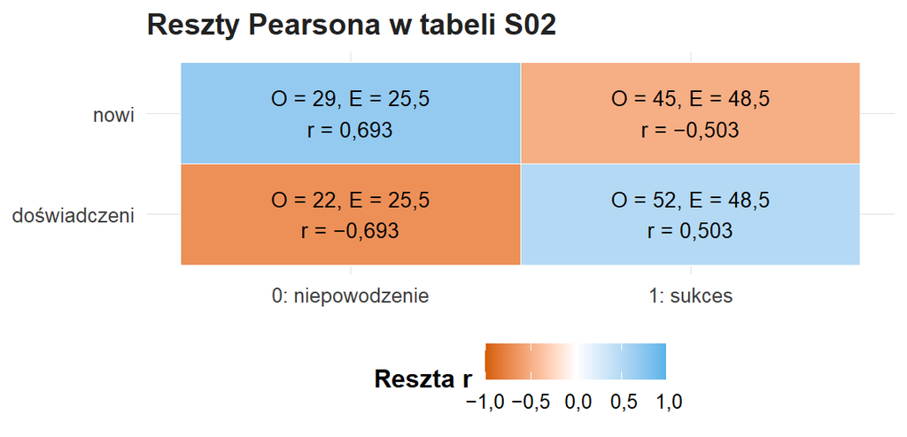

Reszty Pearsona w tabeli S02. Wiersze: grupy; kolumny: wynik zadania. Doświadczeni: niepowodzenie O = 22, E = 25,5, r = −0,693; sukces O = 52, E = 48,5, r = 0,503. Nowi: niepowodzenie O = 29, E = 25,5, r = 0,693; sukces O = 45, E = 48,5, r = −0,503. Kolor niebieski oznacza resztę dodatnią, pomarańczowy — ujemną.

```r
widok <- pokaz_wykres(wykres_reszt)
print(widok)
```

Reszta +0,503 w komórce sukcesów doświadczonych opisuje wzorzec tabeli: więcej sukcesów doświadczonych, niż przewiduje niezależność. Reszty opisują strukturę odchyleń; wyjaśnienie przyczyny wzorca wymaga projektu.

## df, p i jakość przybliżenia

Tabela $r\times c$ ma $(r-1)(c-1)$ stopni swobody; tabela 2 × 2 ma df = 1. Przy ustalonych marginesach jedna komórka wyznacza pozostałe trzy.

Wykres „Rozkłady $\chi^2$ dla df = 1, 2 i 3” przedstawia rozkłady odniesienia testu.

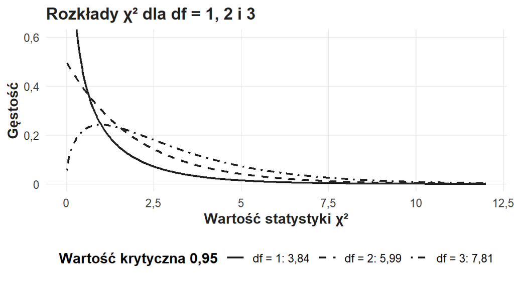

Rozkłady $\chi^2$ dla df = 1, 2 i 3. Oś pozioma: wartość statystyki $\chi^2$; oś pionowa: gęstość. Linia ciągła: df = 1, przerywana: df = 2, kropkowo-kreskowa: df = 3. Wraz z df krzywa przesuwa się w prawo, a wartość krytyczna na poziomie 0,95 rośnie: 3,84, 5,99 i 7,81.

```r
widok <- pokaz_wykres(wykres_chi2_df)
print(widok)
```

Tor klasyczny porównuje $\chi^2$ z rozkładem $\chi^2$(1). Materiał stosuje wersję bez korekty ciągłości, aby tor klasyczny i Monte Carlo używały tej samej statystyki; raport podaje, czy zastosowano korektę.

Tabela „Chi-kwadrat bez korekty ciągłości” podaje N = 148, $\chi^2$ = 1,466, df = 1, p = 0,226, najmniejsze E = 25,5 i 0 komórek z E < 5.

```r
widok <- test_tabeli(wynik)
print(widok)
```

**Chi-kwadrat bez korekty ciągłości**

| Miara | Wartość |
| --- | --- |
| N | 148 |
| Chi-kwadrat | 1,466 |
| df | 1 |
| p | 0,2260 |
| Najmniejsze E | 25,50 |
| Komórki z E < 5 | 0 |

Przy $\alpha$ = 0,05 hipoteza niezależności pozostaje; proporcje w próbie różnią się o 9,46 punktu procentowego, a przedział różnicy obejmuje wartości od −24,7 do 5,8 pp (LEARN 4).

Reguła $E\ge5$ dotyczy przybliżenia; niezależność obserwacji i poprawność kategorii ocenia projekt. Tabela 2 × 2 z komórkami E poniżej 5 wymaga testu Fishera (rozwinięcie „Małe liczebności i test dokładny Fishera”).

## Test z dla dwóch proporcji i chi-kwadrat

Ta sama tabela daje test z dla różnicy dwóch proporcji (wykład W04). Przy $H_0$ obie grupy mają wspólną proporcję $\bar p=97/148=0{,}655$:

$$z=\frac{\widehat\pi_N-\widehat\pi_D}{\sqrt{\bar p(1-\bar p)\left(\frac1{n_N}+\frac1{n_D}\right)}}=\frac{-0{,}0946}{0{,}0781}=-1{,}211,\qquad z^2=1{,}466=\chi^2 .$$

Wykresy „Rozkład N(0, 1) i z = −1,211” oraz „Rozkład $\chi^2$(1) i $\chi^2$ = z² = 1,466” przedstawiają oba rozkłady odniesienia.

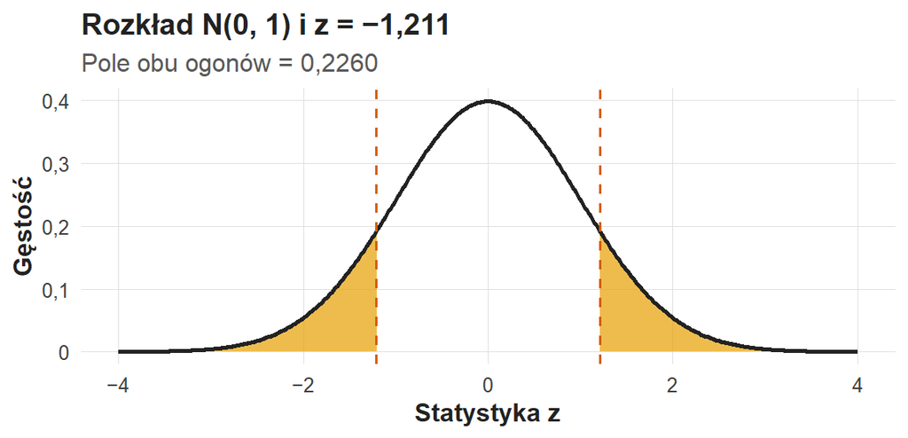

Rozkład N(0, 1) i z = −1,211. Oś pozioma: statystyka z; oś pionowa: gęstość. Zacieniowane ogony na lewo od −1,211 i na prawo od 1,211 mają łączne pole 0,226.

```r
print(pokaz_wykres(wykres_z))
```

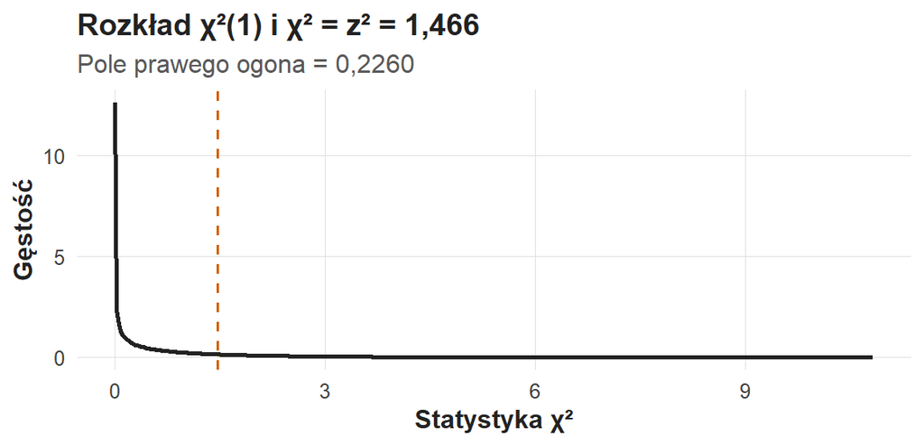

Rozkład $\chi^2$(1) i $\chi^2$ = z² = 1,466. Oś pozioma: statystyka $\chi^2$; oś pionowa: gęstość. Zacieniowany prawy ogon od 1,466 ma pole 0,226, równe polu obu ogonów rozkładu N(0, 1).

```r
print(pokaz_wykres(wykres_chi2_obs))
```

Pole obu ogonów N(0, 1) poza ±1,211 równa się polu ogona $\chi^2$(1) na prawo od 1,466: 0,226. Test z ma znak i daje kierunek, a $\chi^2$ opisuje samą rozbieżność.

**Wzorzec zapisu testu chi-kwadrat (APA).**

> Związek grupy z wynikiem zadania oceniono testem chi-kwadrat bez korekty ciągłości, $\chi^2$(1, *N* = 148) = 1,47, *p* = 0,226; najmniejsza liczebność oczekiwana wyniosła 25,5.

# LEARN 3: Monte Carlo przy ustalonych marginesach

Losowanie tworzy tabele o tych samych marginesach: 74 osoby w każdym wierszu, 51 niepowodzeń i 97 sukcesów w kolumnach. Przy ustalonych marginesach liczba sukcesów doświadczonych ma rozkład hipergeometryczny (wykład W04):

$$P(X=x)=\frac{\binom{n_{\cdot1}}{x}\binom{n_{\cdot0}}{n_{1\cdot}-x}}{\binom{N}{n_{1\cdot}}},$$

gdzie $n_{\cdot1}=97$ i $n_{\cdot0}=51$ to sumy kolumn, a $n_{1\cdot}=74$ — suma pierwszego wiersza. Losowanie zachowuje marginesy i przypisuje tabelom prawdopodobieństwa rozkładu hipergeometrycznego.

Tabela „Jedna tabela z modelu zerowego” ma marginesy 74 i 74 w wierszach oraz 51 i 97 w kolumnach: doświadczeni 25 i 49, nowi 26 i 48.

```r
widok <- losowa_tabela(wynik)
print(widok)
```

**Jedna tabela z modelu zerowego**

| Grupa | 0: niepowodzenie | 1: sukces | Suma |
| --- | --- | --- | --- |
| doświadczeni | 25 | 49 | 74 |
| nowi | 26 | 48 | 74 |
| Suma | 51 | 97 | 148 |

Dla każdej z $B=1999$ tabel funkcja liczy $\chi^2$. Skrajność obejmuje wartości $\chi^2$ co najmniej równe obserwowanej, bo statystyka sumuje odchylenia w obu kierunkach:

$$p_{\mathrm{MC}}=\frac{1+k}{B+1},\qquad k=\#\{b:\ \chi_b^{2*}\geq\chi_{\mathrm{obs}}^2\},$$

gdzie $k$ to liczba losowanych tabel z $\chi^2$ co najmniej równym obserwowanemu. Tabela „Warunkowy test Monte Carlo” podaje $\chi^2$ = 1,466, $k=593$, $B=1999$ i $p_{\mathrm{MC}}=594/2000=0{,}297$. B określa dokładność przybliżenia, a rozkład odniesienia pochodzi z losowanych tabel.

```r
widok <- monte_carlo_tabeli(wynik)
print(widok)
```

**Warunkowy test Monte Carlo**

| Chi-kwadrat obserwowane | Tabele co najmniej tak skrajne (k) | B | p_MC |
| --- | --- | --- | --- |
| 1,466 | 593 | 1999 | 0,2970 |

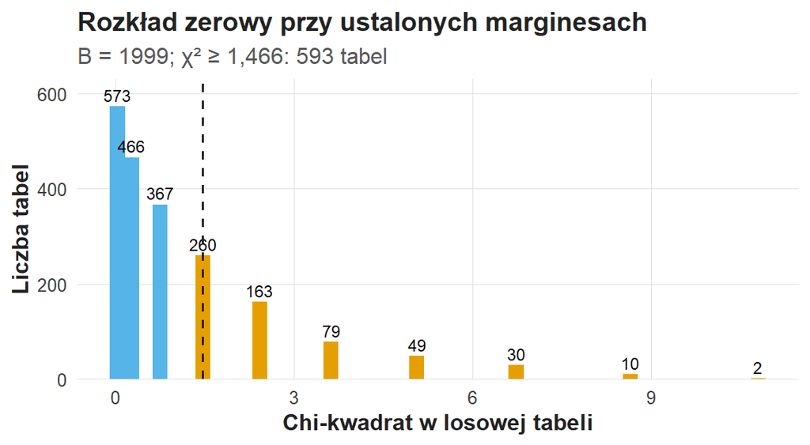

Rozkład zerowy przy ustalonych marginesach: liczby 1999 losowanych tabel według wartości $\chi^2$. Oś pozioma: $\chi^2$ w losowej tabeli; oś pionowa: liczba tabel. Statystyka przyjmuje tylko kilka wartości: 0,03 (573 tabele), 0,27 (466), 0,75 (367), 1,47 (260), 2,42 (163) i dalsze; linia przerywana przy 1,466 oznacza wartość z S02, a 593 tabele leżą na niej lub na prawo.

```r
widok <- pokaz_wykres(wykres_zerowy)
print(widok)
```

P klasyczne (0,226) i Monte Carlo (0,297) różnią się, bo rozkład tabel przy stałych marginesach jest dyskretny: 260 tabel ma $\chi^2$ równe obserwowanemu 1,47 i wszystkie wchodzą do licznika. Wykres „Ogon Monte Carlo i ogon $\chi^2$(1)” zestawia oba ogony.

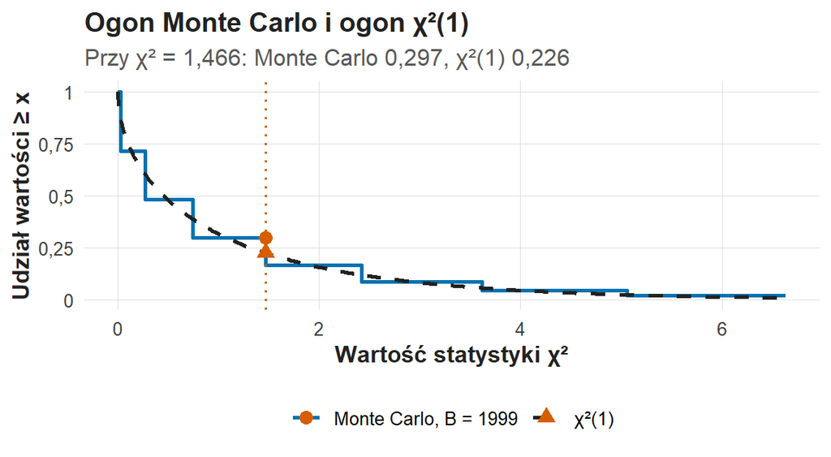

Ogon Monte Carlo i ogon $\chi^2$(1). Oś pozioma: wartość $\chi^2$; oś pionowa: udział wartości co najmniej x. Linia schodkowa: 1999 losowanych tabel; linia przerywana: rozkład $\chi^2$(1). Przy obserwowanym $\chi^2$ = 1,466 (linia kropkowana) ogon Monte Carlo wynosi 0,297 (koło), a ogon $\chi^2$(1) — 0,226 (trójkąt); schodek przy 1,47 zawiera remisy.

```r
widok <- pokaz_wykres(wykres_ogona)
print(widok)
```

W obu torach hipoteza niezależności pozostaje przy $\alpha$ = 0,05. Ten sam schemat realizuje funkcja `chisq.test(..., simulate.p.value = TRUE)`; [dokumentacja chisq.test](https://stat.ethz.ch/R-manual/R-devel/library/stats/html/chisq.test.html) opisuje zachowanie marginesów. Funkcja pomocnicza `analiza_tabeli()` zwraca losowane statystyki, więc $p_{\mathrm{MC}}$ wynika wprost z losowanych tabel.

**Wzorzec zapisu testu Monte Carlo (APA).**

> Test Monte Carlo przy ustalonych marginesach (*B* = 1999) dał *p*<sub>MC</sub> = 0,297, ponieważ 593 losowane tabele miały statystykę $\chi^2$ co najmniej równą obserwowanej.

# LEARN 4: efekt w punktach procentowych i jego niepewność

Estymandą kierunkową jest $\Delta_\pi=\pi_{\mathrm{nowi}}-\pi_{\mathrm{doświadczeni}}$. Estymata wynosi $45/74-52/74=-7/74=-0{,}0946$, czyli −9,46 punktu procentowego. Zapis w punktach procentowych odróżnia różnicę bezwzględną od zmiany względnej (−13,5%, rozwinięcie „Punkty procentowe, iloraz proporcji i iloraz szans”).

Tabela „Efekt: sukces wiersza 2 minus sukces wiersza 1” podaje różnicę jako proporcję (−0,0946) i w punktach procentowych (−9,46) oraz V = 0,0995. V opisuje siłę związku.

```r
widok <- efekty_tabeli(wynik)
print(widok)
```

**Efekt: sukces wiersza 2 minus sukces wiersza 1**

| Miara | Wartość |
| --- | --- |
| Różnica proporcji | -0,0946 |
| Różnica [punkty procentowe] | -9,4595 |
| V Craméra | 0,0995 |

Przybliżone SE różnicy proporcji niezależnych grup i przedział Walda mają postać:

$$SE(\widehat\Delta_\pi)=
\sqrt{\frac{\widehat\pi_N(1-\widehat\pi_N)}{n_N}+
\frac{\widehat\pi_D(1-\widehat\pi_D)}{n_D}}=0{,}0777,\qquad
\widehat\Delta_\pi\pm1{,}96\,SE=-9{,}46\pm15{,}2\ \text{pp}.$$

Przedział Walda działa dobrze przy dużych N i proporcjach dalekich od 0 i 1; przy rzadkich komórkach stosuje się metody dokładne.

Tabela „95% CI różnicy [punkty procentowe]” zestawia przedział Walda z percentylowym bootstrapem różnicy przy losowaniu osobno w grupach: Wald od −24,70 do 5,78 pp, bootstrap od −24,32 do 5,41 pp. Oba przedziały dotyczą różnicy proporcji.

```r
widok <- przedzialy_tabeli(wynik)
print(widok)
```

**95% CI różnicy [punkty procentowe]**

| Metoda | Estymata [pp] | Dolna granica [pp] | Górna granica [pp] |
| --- | --- | --- | --- |
| Wald bez korekty | -9,46 | -24,70 | 5,78 |
| Bootstrap w grupach | -9,46 | -24,32 | 5,41 |

Przedziały obejmują różnice w obu kierunkach, także skuteczność nowych niższą o ponad 20 punktów procentowych. Szerokość przedziału wynosi około 30 punktów procentowych.

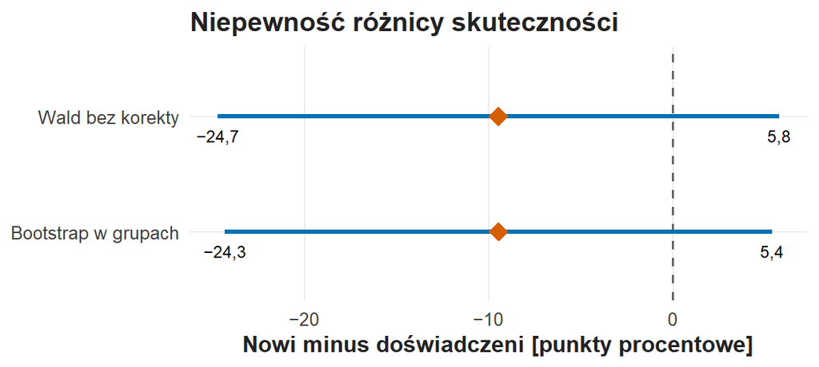

Niepewność różnicy skuteczności nowi minus doświadczeni w punktach procentowych. Wald bez korekty: od −24,7 do 5,8; bootstrap w grupach: od −24,3 do 5,4; romby przy −9,5; oba odcinki przecinają linię przerywaną zera.

```r
widok <- pokaz_wykres(wykres_ci)
print(widok)
```

Wykazanie równoważności wymaga progu tolerancji i testu równoważności; przedział obejmuje różnice praktycznie ważne.

## V Craméra: siła związku

Dla tabeli o $r$ wierszach i $c$ kolumnach:

$$V=\sqrt{\frac{\chi^2}{N\min(r-1,c-1)}},\qquad \text{w tabeli 2 × 2: } V=\sqrt{\frac{\chi^2}{N}}=\frac{|z|}{\sqrt N}=\frac{1{,}211}{\sqrt{148}}=0{,}0995 .$$

Wzór brzmi słownie: statystykę $\chi^2$ dzieli się przez liczebność i mniejszą liczbę kategorii pomniejszoną o jeden, a następnie wyciąga pierwiastek. Wszystkie składniki są nieujemne, więc V jest nieujemne i pozostaje takie samo po zamianie kolejności grup, a różnica proporcji zmienia wtedy znak.

V = 0,100 opisuje natężenie odstępstwa od niezależności; kierunek podaje różnica proporcji.

Próg praktycznej ważności wynika z kontekstu zadania: ta sama różnica skuteczności ma inne znaczenie przy wyszukaniu lektury i przy pilnej informacji o świadczeniu. Raport podaje najpierw efekt w jednostkach zrozumiałych dla odbiorcy, a potem miarę standaryzowaną.

Test niezależności wykonuje $\chi^2$, Fisher albo Monte Carlo; percentyle bootstrapu V opisują zmienność V. Tabela „Bootstrap V w S02: opis zmienności” podaje V = 0,100 oraz percentyle 0 i 0,262 z 1999 prób.

```r
widok <- bootstrap_V_s02()
print(widok)
```

**Bootstrap V w S02: opis zmienności**

| Miara | Wartość |
| --- | --- |
| V obserwowane | 0,100 |
| Percentyl 2,5% | 0,000 |
| Percentyl 97,5% | 0,262 |
| B | 1999 |

Zero leży na granicy zakresu V, więc przedział percentylowy V opisuje zmienność miary; kontrprzykład podaje rozwinięcie „V przy granicy zera”.

**Wzorzec zapisu efektu z przedziałem (APA).**

> Odsetek sukcesów nowych był niższy o 9,46 punktu procentowego, 95% CI [−24,70; 5,78] (przedział Walda); *V* = 0,10.

# LEARN 5: wynik a pytanie o usługę

## Wzorzec zapisu wyniku

**Wzorzec zapisu wyniku tabeli 2 × 2 (APA).**

> W syntetycznej próbie 148 użytkowników sukces w zadaniu uzyskało 45 z 74 nowych osób (60,8%) i 52 z 74 doświadczonych (70,3%). Różnica nowi minus doświadczeni wyniosła −9,46 punktu procentowego, 95% CI [−24,70; 5,78] (przedział Walda). Test chi-kwadrat bez korekty ciągłości dał $\chi^2$(1, *N* = 148) = 1,47, *p* = 0,226, przy wszystkich liczebnościach oczekiwanych powyżej 5, a test Monte Carlo przy ustalonych marginesach (*B* = 1999) — *p*<sub>MC</sub> = 0,297; *V* = 0,10.

> Hipoteza niezależności pozostaje przy $\alpha$ = 0,05, a przedział obejmuje różnice praktycznie ważne. Wynik dotyczy sukcesu w jednym zadaniu; dobór i brak przydziału ograniczają uogólnienie.

W CHALLENGE liczby odczytujesz z wyników archiwum; estymata i przedział pochodzą z tej samej analizy, a raport nazywa metodę przedziału i rzeczywiste B.

## Kompletność opisu

Pierwsze zdanie akapitu określa osoby, wynik i mianowniki. Drugie podaje efekt w jednostkach usługi i niepewność estymacji. Trzecie przechodzi do rozbieżności od niezależności i procedury obliczania p. Wniosek wraca do skuteczności i granic pomiaru.

Przedział od −25 do +6 punktów procentowych obejmuje skuteczność nowych niższą o ponad 20 punktów procentowych; twierdzenia o zbędności wsparcia i skuteczności szkolenia wymagają osobnego badania.

W S02 najmniejsze E wynosi 25,5, więc przybliżenie $\chi^2$ jest adekwatne. Przy małych oczekiwaniach w tabeli 2 × 2 podstawowym wynikiem jest test Fishera, raportowany z nazwą testu, OR warunkowym, przedziałem i p.

## Korekta zbyt mocnego wniosku

Zdanie „p = 0,297 dowodzi, że grupy są równe i mają te same kompetencje” zawiera dwa błędy. Wartość p opisuje skrajność danych przy $H_0$; sukces w jednym wyszukaniu mierzy wycinek kompetencji. Poprawny opis brzmi: w syntetycznej próbie nowe osoby miały niższą skuteczność, a szeroki przedział pozostawia otwarte pytanie o równość w populacji i o różnice całego konstruktu kompetencji.

Deklaracja znajomości narzędzia, wcześniejsze korzystanie i obserwowany sukces są w badaniach informacji trzema wskaźnikami; każdy wskaźnik zachowuje własną nazwę. Badania Hargittai nad obserwowanymi umiejętnościami i prace o skalach umiejętności internetowych uzasadniają rozdzielenie pomiarów; liczby ćwiczenia pochodzą z generatora kursu.

# CHALLENGE — kto odnajduje dokument w archiwum cyfrowym

Odrębne syntetyczne badanie obserwacyjne zarejestrowało 126 osób korzystających z archiwum cyfrowego. Grupa „powracający” używała archiwum wcześniej, a grupa „pierwsza wizyta” odwiedza serwis po raz pierwszy; grupy wynikają z historii korzystania. Sukces (kod 1) oznacza odnalezienie wskazanego dokumentu, a niepowodzenie (kod 0) — zakończenie próby bez niego. Różnicę liczy się w kierunku pierwsza wizyta minus powracający.

Każde z pięciu zadań ma ten sam układ:

1. **Zadanie** — jedno zdanie z przedmiotem opisu.
2. **Blok R** — uruchom go; wynik zawiera wszystkie liczby potrzebne do odpowiedzi.
3. **Wskazówki** — gdzie w wyniku szukać informacji, jak ją nazwać i wzór zdania do uzupełnienia.
4. **W akapicie wymagane** — elementy, które sprawdza prowadzący.
5. **Twój akapit** — pole odpowiedzi w ramce: znacznik w nawiasie kwadratowym zastępujesz własnym tekstem, a linie komentarza nad nim i pod nim pozostawiasz bez zmian.

Akapit liczy 3–5 zdań zwykłego tekstu, bez kodu R. Liczby przepisujesz z wyniku bloku, z jednostką, symbolem i mianownikiem.

## CHALLENGE 1: Jednostka, sukces i mianowniki

**Zadanie:** nazwij jednostkę, kryterium sukcesu i estymandę oraz opisz, ile osób wchodzi do tabeli.

```r
bilans <- bilans_archiwum()
print(bilans)
```

**Od rejestracji do ważnego wyniku**

| Grupa | Zarejestrowani | Brak wyniku | W tabeli |
| --- | --- | --- | --- |
| powracający | 42 | 2 | 40 |
| pierwsza wizyta | 84 | 4 | 80 |

**Tabela wyników zadania**

| Grupa | 0: niepowodzenie | 1: sukces |
| --- | --- | --- |
| powracający | 10 | 30 |
| pierwsza wizyta | 32 | 48 |

Blok wyświetla tabelę „Od rejestracji do ważnego wyniku” (zarejestrowani, brak wyniku i osoby w tabeli dla każdej grupy) oraz „Tabela wyników zadania” z komórkami 0 i 1.

*Wskazówki:*

- Jednostką jest osoba ze znaną grupą i znanym wynikiem zadania; osoba z brakiem wyniku pozostaje poza tabelą, a brak różni się od niepowodzenia 0.
- Estymanda: prawdopodobieństwo sukcesu przy pierwszej wizycie minus prawdopodobieństwo sukcesu u powracających.
- Grupy są niezależne, bo każda osoba należy do jednej grupy i ma jeden wynik.
- Wzorzec APA: „Analiza objęła [N] z [..] zarejestrowanych osób: [n] powracających ([..] brak wyniku) i [n] przy pierwszej wizycie ([..] braki). Sukcesem było [kryterium]; estymandą jest różnica prawdopodobieństw sukcesu (pierwsza wizyta minus powracający)”.

*W akapicie wymagane:* (i) jednostka i kryterium sukcesu; (ii) estymanda z kierunkiem; (iii) N w obu grupach i liczba braków; (iv) traktowanie braków; (v) uzasadnienie niezależności grup.

**Twój akapit S01.** Znacznik w nawiasie kwadratowym zastąp własnym tekstem.

## CHALLENGE 2: Liczba sukcesów i odsetek sukcesów

**Zadanie:** porównaj skuteczność obu grup odsetkami i odróżnij odsetek w grupie od udziału grupy wśród sukcesów.

```r
odsetki <- mianowniki_archiwum()
print(odsetki)
```

**N grup i sukcesy**

| Grupa | N | Sukcesy | Sukcesy [%] |
| --- | --- | --- | --- |
| powracający | 40 | 30 | 75 |
| pierwsza wizyta | 80 | 48 | 60 |

**Odsetki w grupach [%]**

| Grupa | 0: niepowodzenie | 1: sukces |
| --- | --- | --- |
| powracający | 25 | 75 |
| pierwsza wizyta | 40 | 60 |

**Skład kategorii wyniku [%]**

| Grupa | 0: niepowodzenie | 1: sukces |
| --- | --- | --- |
| powracający | 23,81 | 38,46 |
| pierwsza wizyta | 76,19 | 61,54 |

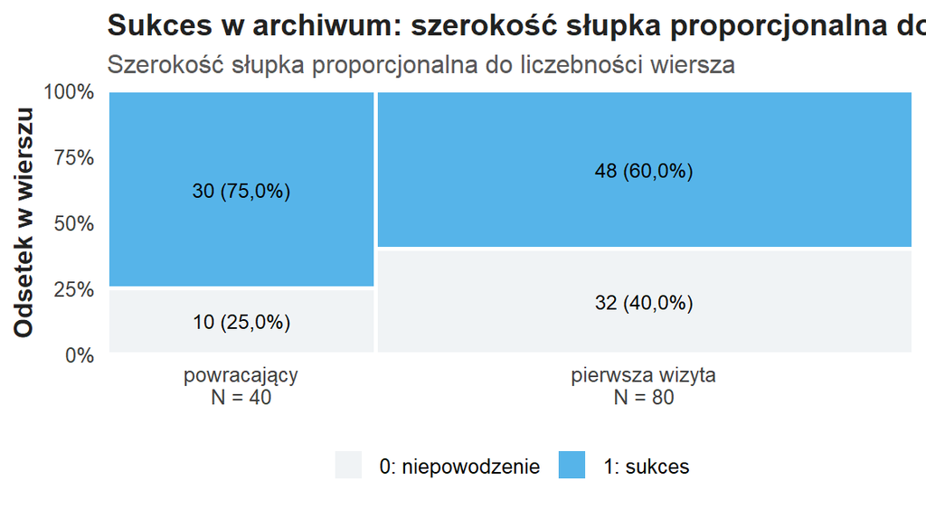

Sukces w archiwum: wykres mozaikowy. Szerokość słupka jest proporcjonalna do N grupy, pod słupkiem podano N, a etykiety w odcinkach podają liczbę osób i odsetek w grupie; oś pionowa: odsetek w wierszu.

Blok wyświetla tabele „N grup i sukcesy”, „Odsetki w grupach [%]” i „Skład kategorii wyniku [%]” oraz wykres mozaikowy.

*Wskazówki:*

- Grupa pierwszej wizyty ma więcej sukcesów w liczbach bezwzględnych, bo jest dwukrotnie liczniejsza; skuteczność porównuje się odsetkami w grupach.
- Odczyt 48/80 to odsetek sukcesów wśród osób przy pierwszej wizycie (tabela „Odsetki w grupach [%]”); odczyt 48/78 to udział tej grupy wśród wszystkich 78 sukcesów (tabela „Skład kategorii wyniku [%]”).
- Na wykresie szerokość słupka pokazuje N grupy, a wysokość odcinka — odsetek w grupie.
- Wzorzec APA: „Wskazany dokument znalazło [x] z [n] powracających ([..]%) i [x] z [n] osób przy pierwszej wizycie ([..]%)”.

*W akapicie wymagane:* (i) liczby sukcesów i odsetki obu grup z mianownikami; (ii) grupa z większą liczbą sukcesów i grupa z wyższym odsetkiem; (iii) znaczenie i wartość odczytów 48/80 i 48/78; (iv) jedna cecha wykresu powiązana z N grup.

**Twój akapit S02.** Znacznik w nawiasie kwadratowym zastąp własnym tekstem.

## CHALLENGE 3: Od hipotezy do statystyki i dwóch p

**Zadanie:** zapisz hipotezę niezależności, odtwórz liczebność oczekiwaną i wkład jednej komórki oraz odczytaj oba testy.

```r
testy <- testy_archiwum()
print(testy)
```

**E przy niezależności**

| Grupa | 0: niepowodzenie | 1: sukces |
| --- | --- | --- |
| powracający | 14 | 26 |
| pierwsza wizyta | 28 | 52 |

**Wkłady do chi-kwadrat**

| Grupa | 0: niepowodzenie | 1: sukces |
| --- | --- | --- |
| powracający | 1,143 | 0,615 |
| pierwsza wizyta | 0,571 | 0,308 |

**Chi-kwadrat bez korekty**

| Miara | Wartość |
| --- | --- |
| N | 120 |
| Chi-kwadrat | 2,637 |
| df | 1 |
| p | 0,1044 |
| Najmniejsze E | 14,00 |
| Komórki z E < 5 | 0 |

**Warunkowe Monte Carlo**

| Chi-kwadrat obserwowane | Tabele co najmniej tak skrajne (k) | B | p_MC |
| --- | --- | --- | --- |
| 2,637 | 297 | 1999 | 0,1490 |

Blok wyświetla tabele „E przy niezależności”, „Wkłady do chi-kwadrat”, „Chi-kwadrat bez korekty” (N, statystyka, df, p, najmniejsze E, komórki z E poniżej 5) i „Warunkowe Monte Carlo” (statystyka obserwowana, liczba tabel co najmniej tak skrajnych k, B i $p_{\mathrm{MC}}$).

*Wskazówki:*

- $H_0$: sukces w zadaniu jest niezależny od grupy, czyli prawdopodobieństwo sukcesu jest w obu grupach takie samo.
- $E=\text{suma wiersza}\cdot\text{suma kolumny}/N$: dla sukcesu przy pierwszej wizycie podstaw 80 osób w wierszu, 78 sukcesów w kolumnie i N = 120.
- Wkład komórki to $(O-E)^2/E$; statystyka $\chi^2$ jest sumą czterech wkładów.
- Najmniejsze E co najmniej 5 uzasadnia przybliżenie rozkładem $\chi^2(1)$; $p_{\mathrm{MC}}=(k+1)/(B+1)$.
- Wartość p opisuje skrajność danych przy prawdziwej $H_0$.
- Wzorzec APA: „Test niezależności dał $\chi^2$(1, *N* = [..]) = [..], *p* = [..] (najmniejsza liczebność oczekiwana [..]), a test Monte Carlo przy ustalonych marginesach (*B* = [..]) *p*<sub>MC</sub> = ([k] + 1)/([B] + 1) = [..]”.

*W akapicie wymagane:* (i) $H_0$ językiem powodzenia zadania; (ii) E dla sukcesu przy pierwszej wizycie z licznikiem i mianownikiem wzoru; (iii) wkład tej komórki; (iv) statystyka, df, p i najmniejsze E; (v) k, B i $p_{\mathrm{MC}}$ z rachunkiem oraz znaczenie p.

**Twój akapit S03.** Znacznik w nawiasie kwadratowym zastąp własnym tekstem.

## CHALLENGE 4: Efekt z kierunkiem i przedziałem

**Zadanie:** opisz różnicę skuteczności w punktach procentowych z dwoma przedziałami i odczytaj V bez kierunku.

```r
efekt <- efekt_archiwum()
print(efekt)
```

**Efekt: sukces wiersza 2 minus sukces wiersza 1**

| Miara | Wartość |
| --- | --- |
| Różnica proporcji | -0,150 |
| Różnica [punkty procentowe] | -15,000 |
| V Craméra | 0,148 |

**95% CI różnicy [punkty procentowe]**

| Metoda | Estymata [pp] | Dolna granica [pp] | Górna granica [pp] |
| --- | --- | --- | --- |
| Wald bez korekty | -15 | -32,185 | 2,185 |
| Bootstrap w grupach | -15 | -32,562 | 2,500 |

Blok wyświetla tabelę „Efekt: sukces wiersza 2 minus sukces wiersza 1” (różnica proporcji, różnica w punktach procentowych i V Craméra) oraz tabelę „95% CI różnicy [punkty procentowe]” (Wald bez korekty i bootstrap w grupach).

*Wskazówki:*

- Wiersz 2 to pierwsza wizyta, a wiersz 1 — powracający: ujemna różnica oznacza niższy odsetek sukcesów przy pierwszej wizycie.
- Przedział obejmujący zero pozostawia otwarte kierunek i wielkość różnicy w populacji; odczytaj, jak duże różnice obejmuje.
- V jest nieujemne i opisuje natężenie związku; kierunek podaje różnica odsetków.
- Wniosek o związku opiera się na teście z CHALLENGE 3, a opis wielkości — na przedziale.
- Wzorzec APA: „Odsetek sukcesów przy pierwszej wizycie był niższy o [..] punktu procentowego, 95% CI [[..]; [..]] (przedział Walda), a percentylowy przedział bootstrapowy wyniósł [[..]; [..]]; *V* = [..]”.

*W akapicie wymagane:* (i) różnica proporcji i jej zapis w punktach procentowych; (ii) oba 95% CI z nazwami metod; (iii) kierunki i wielkości różnic zgodne z przedziałami; (iv) V jako natężenie bez kierunku; (v) źródło kierunku efektu.

**Twój akapit S04.** Znacznik w nawiasie kwadratowym zastąp własnym tekstem.

## CHALLENGE 5: Odpowiedź dla zespołu archiwum

Zespół proponuje zdanie do raportu: „Ponieważ p jest większe od 0,05, wszyscy korzystają z archiwum równie skutecznie i nie potrzeba wsparcia”. Zespół przyjął przed analizą różnicę 10 punktów procentowych jako ważną dla usługi.

**Zadanie:** zastąp zdanie zespołu akapitem raportowym i oceń, czy wyniki wykluczają różnicę 10 punktów procentowych na niekorzyść pierwszej wizyty.

```r
podsumowanie <- odpowiedz_archiwum()
print(podsumowanie)
```

**N grup i sukcesy**

| Grupa | N | Sukcesy | Sukcesy [%] |
| --- | --- | --- | --- |
| powracający | 40 | 30 | 75 |
| pierwsza wizyta | 80 | 48 | 60 |

**Efekt: sukces wiersza 2 minus sukces wiersza 1**

| Miara | Wartość |
| --- | --- |
| Różnica proporcji | -0,150 |
| Różnica [punkty procentowe] | -15,000 |
| V Craméra | 0,148 |

**95% CI różnicy [punkty procentowe]**

| Metoda | Estymata [pp] | Dolna granica [pp] | Górna granica [pp] |
| --- | --- | --- | --- |
| Wald bez korekty | -15 | -32,185 | 2,185 |
| Bootstrap w grupach | -15 | -32,562 | 2,500 |

**Dwa testy niezależności**

| Chi-kwadrat | df | p | Najmniejsze E | p_MC | B |
| --- | --- | --- | --- | --- | --- |
| 2,637 | 1 | 0,1044 | 14 | 0,1490 | 1999 |

Blok wyświetla tabele „N grup i sukcesy”, „Efekt: sukces wiersza 2 minus sukces wiersza 1”, „95% CI różnicy [punkty procentowe]” i „Dwa testy niezależności” (statystyka, df, p, najmniejsze E, $p_{\mathrm{MC}}$ i B) — komplet liczb do akapitu.

*Wskazówki:*

- Zdanie zespołu myli pozostawienie $H_0$ z dowodem równej skuteczności; równoważność wymaga przedziału leżącego w całości wewnątrz progu tolerancji.
- Porównaj przedział różnicy z wartością −10 pp: przedział obejmujący −10 pozostawia taką różnicę zgodną z danymi.
- Ograniczenia: jedno zadanie, grupy obserwacyjne, 6 osób z brakiem wyniku.
- Następna czynność: np. zadania o różnej trudności albo pomiar przyczyn niepowodzenia przy pierwszej wizycie.
- Wzorzec APA: „Dokument znalazło [x] z [n] powracających ([..]%) i [x] z [n] osób przy pierwszej wizycie ([..]%); różnica wyniosła [..] pp, 95% CI [[..]; [..]], $\chi^2$(1, *N* = [..]) = [..], *p* = [..], *p*<sub>MC</sub> = [..]. Przedział obejmuje różnicę −10 pp, więc wyniki pozostawiają otwartą ważną dla usługi różnicę na niekorzyść pierwszej wizyty; [ograniczenie i następna czynność]”.

*W akapicie wymagane:* (i) N i odsetki obu grup; (ii) kierunek różnicy z przedziałem; (iii) odczyt obu p; (iv) ocena różnicy 10 pp na podstawie przedziału; (v) ograniczenie pomiaru lub doboru i następna czynność badawcza, z różnicą opisaną jako związek historii korzystania z sukcesem.

**Twój akapit S05.** Znacznik w nawiasie kwadratowym zastąp własnym tekstem.

# Zapis i oddanie

Sprawdź pięć własnych odpowiedzi: każde „więcej” ma wskazaną grupę odniesienia, każdy procent — właściwy mianownik, a znak różnicy odpowiada kolejności grup. Statystyka korzysta ze 120 osób ze znanym wynikiem. Zapisz plik `zadanie.Rmd` w edytorze (Ctrl+S); funkcja oddania tworzy PDF z zapisanego pliku.

W konsoli wykonaj jedno polecenie. Funkcja oddania tworzy aktualny PDF, sprawdza kompletność, otwiera PDF do obejrzenia i po potwierdzeniu literą `t` wysyła go do folderu zadania prowadzącego na serwerze UJ (nc.uj.edu.pl). Nazwa pliku zawiera Twoje ID oraz nazwisko i imię.

```r
oddaj_zadanie("Z07")
```

Oddanie potwierdza komunikat z nazwą wysłanego pliku, folderem i czasem; plik `oddania.csv` w folderze `moje-badania` zapisuje także sumę SHA-256 wysłanego PDF. Po komunikacie błędu popraw wskazany problem, zapisz plik i ponownie wywołaj `oddaj_zadanie("Z07")`; nowa wersja trafia do folderu obok poprzedniej. Ocenę prowadzący przekazuje osobno.

Po potwierdzonym oddaniu możesz zamknąć projekt: Posit Cloud zachowuje folder `moje-badania` do kolejnych zajęć. Na komputerze współdzielonym wyloguj się z Posit Cloud w przeglądarce. Przy braku sieci PDF pozostaje w folderze zadania; wyślij go tym samym poleceniem po odzyskaniu połączenia, a gdy problem trwa, poproś prowadzącego o ustalenie sposobu dostarczenia pracy.

## Co jest oceniane

| Kryterium | Dowód w Twojej pracy | Odpowiedzi | Punkty |
| --- | --- | --- | --- |
| Z07.1 Uzasadnienie tabeli i warunków wnioskowania | Jednostka, sukces, niezależne grupy i różnica prawdopodobieństw; $H_0$, najmniejsze E, przybliżenie $\chi^2$ i Monte Carlo przy stałych marginesach; braki poza tabelą | S01, S03 | 2 |
| Z07.2 Liczebności i dwa różne mianowniki odsetka | N obu grup i braki; 48/80 i 48/78; liczby i odsetki sukcesów powiązane ze słupkami 100% i z N grup | S01, S02 | 3 |
| Z07.3 Statystyka, dwa p oraz kierunkowy efekt z CI | Wzór E, wkład komórki, $\chi^2$, df i p; k, B i $(k+1)/(B+1)$; różnica w punktach procentowych, oba 95% CI i V bez kierunku | S03, S04 | 3 |
| Z07.4 Wniosek dla archiwum bez pozornej równoważności | Akapit z N, odsetkami, kierunkiem, CI i oboma p; ocena różnicy 10 pp; ograniczenie i następna czynność badawcza | S02, S05 | 2 |

Ocena dotyczy zgodności zdania z danymi; punkty przyznaje się za wyjaśnienie znaczenia wartości. Poziomy wykonania opisuje rubryka Z07: na stronie kursu w dokumencie `rubryki/Z07.html`, a w konsoli R po poleceniu `rubryka("Z07")`.

# Rozwinięcia do powtórki — poza rdzeniem spotkania

Rozwinięcia rozwijają granice metod: V przy zerze, małe liczebności, miary względne, skalowanie N, więcej kategorii i pomiar przed–po. Rozwinięcia służą powtórce i pozostają poza oceną.

## V przy granicy zera

Percentyle bootstrapu V pochodzą z losowania osób ze zwracaniem osobno w grupach i opisują zmienność nieujemnej miary. Przy niezależności losowa tabela zwykle ma nierówne proporcje, więc jej V jest dodatnie, a rozkład V zaczyna się od zera.

### Kontrprzykład: dodatnia granica percentyla przy niezależności

Druga tabela zawiera 200 hipotetycznych obserwacji: doświadczeni 50 niepowodzeń i 47 sukcesów, nowi 53 niepowodzenia i 50 sukcesów. Proporcje sukcesu w grupach są niemal identyczne: 48,45% i 48,54%.

```r
widok <- v_przy_zerze()
print(widok)
```

**Tabela bliska niezależności**

| Grupa | 0: niepowodzenie | 1: sukces |
| --- | --- | --- |
| doświadczeni | 50 | 47 |
| nowi | 53 | 50 |

**Test niezależności**

| Miara | Wartość |
| --- | --- |
| N | 200 |
| Chi-kwadrat | 0,000 |
| df | 1 |
| p | 0,9898 |
| Najmniejsze E | 47,05 |
| Komórki z E < 5 | 0 |

**Opis rozkładu bootstrapowego V**

| Miara | Wartość |
| --- | --- |
| V obserwowane | 0,0009 |
| Percentyl 2,5% | 0,0015 |
| Percentyl 97,5% | 0,1514 |
| B | 1999 |

Tabele podają $\chi^2$ = 0,00016, p = 0,990 i V = 0,0009, a dolny percentyl bootstrapu V wynosi 0,0015 — powyżej zera przy tabeli niemal idealnie niezależnej. Wniosek „przedział nie obejmuje zera, więc związek jest istotny” jest przy tabeli bliskiej niezależności błędny.

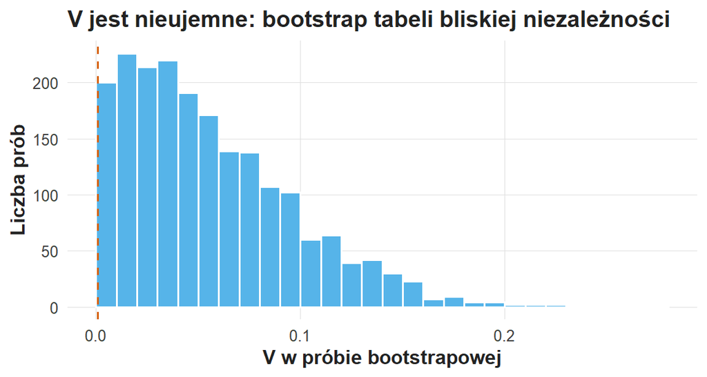

V jest nieujemne: histogram 1999 wartości V z bootstrapu tabeli bliskiej niezależności, przedziały po 0,01. Oś pozioma: V w próbie bootstrapowej; oś pionowa: liczba prób. Wszystkie wartości są dodatnie, od 0,0003 do 0,27; linia przerywana obserwowanego V = 0,0009 leży przy lewym krańcu.

```r
widok <- pokaz_wykres(wykres_V)
print(widok)
```

Procedurę dopasowuje się do parametru, jego granic i pytania: niezależność testuje $\chi^2$ lub Fisher, a niepewność efektu opisuje przedział różnicy proporcji.

Po zamianie grup V pozostaje nieujemne i takie samo; różnica zmienia znak, a granice jej przedziału zamieniają się miejscami ze zmianą znaku. Obie własności służą kontroli kierunku w tabeli i raporcie.

## Małe liczebności i test dokładny Fishera

Biblioteka sprawdza nowy sposób dostępu do bazy w pilotażu z dziesięcioma osobami w każdej grupie, więc kontrola oczekiwań jest konieczna. Tabele „Obserwacje” i „Oczekiwania” podają: doświadczeni — 3 niepowodzenia i 7 sukcesów, nowi — 9 niepowodzeń i 1 sukces; oczekiwania 6 i 4 w każdym wierszu. Liczebność obserwowana i oczekiwana to dwie wielkości.

```r
widok <- rzadka_tabela_do_odczytu()
print(widok)
```

**Obserwacje**

| Grupa | 0: niepowodzenie | 1: sukces |
| --- | --- | --- |
| doświadczeni | 3 | 7 |
| nowi | 9 | 1 |

**Oczekiwania**

| Grupa | 0: niepowodzenie | 1: sukces |
| --- | --- | --- |
| doświadczeni | 6 | 4 |
| nowi | 6 | 4 |

Dwie oczekiwane liczebności równe 4 wskazują test dokładny Fishera, który warunkuje na ustalonych sumach brzegowych. Przy sumach 10 i 10 w wierszach oraz 12 i 8 w kolumnach liczba sukcesów doświadczonych ma rozkład hipergeometryczny.

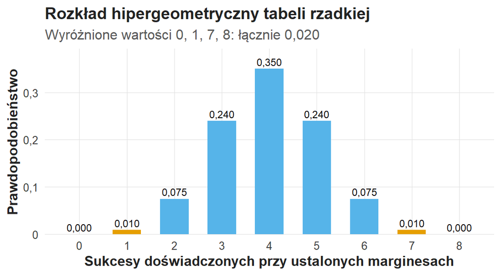

Rozkład hipergeometryczny tabeli rzadkiej: prawdopodobieństwo liczby sukcesów doświadczonych przy ustalonych marginesach. Oś pozioma: liczba sukcesów od 0 do 8; oś pionowa: prawdopodobieństwo. Słupki są symetryczne wokół 4 (0,350); wyróżnione wartości 0, 1, 7 i 8 mają łączne prawdopodobieństwo 0,020, czyli dwustronne p Fishera.

```r
widok <- pokaz_wykres(wykres_hipergeometryczny)
print(widok)
```

Trzy procedury mają trzy rozkłady odniesienia; metodę główną ustala się przed analizą. Tabele podają: $\chi^2$ = 7,5, p = 0,0062, najmniejsze E = 4 i 2 komórki z E < 5; Fisher — OR warunkowe 0,058, przedział od 0,001 do 0,721, p = 0,0198; Monte Carlo — $p_{\mathrm{MC}}$ = 0,0255.

```r
widok <- rzadkie_testy_do_odczytu()
print(widok)
```

**Przybliżenie chi-kwadrat**

| Miara | Wartość |
| --- | --- |
| N | 20 |
| Chi-kwadrat | 7,500 |
| df | 1 |
| p | 0,0062 |
| Najmniejsze E | 4,00 |
| Komórki z E < 5 | 2 |

**Dokładny test Fishera**

| Miara | Wartość |
| --- | --- |
| OR warunkowe | 0,058 |
| Dolna granica 95% CI | 0,001 |
| Górna granica 95% CI | 0,721 |
| p Fishera | 0,0198 |

**Warunkowe Monte Carlo**

| Chi-kwadrat obserwowane | Tabele co najmniej tak skrajne (k) | B | p_MC |
| --- | --- | --- | --- |
| 7,5 | 50 | 1999 | 0,0255 |

Różnica 0,0062 i 0,0198 wynika z dyskretności tabeli. Raport podaje nazwę testu razem z p.

OR warunkowe (0,058) różni się od OR surowego $(1/9)/(7/3)=0{,}048$; wynik Fishera opisuje się nazwą testu, OR, przedziałem i p.

Test dokładny działa przy komórce zerowej; pusty wiersz lub kolumna oznacza brak kategorii i wymaga sprawdzenia rejestracji.

p opisuje skrajność tabeli przy $H_0$; wniosek przyczynowy wymaga losowego przydziału.

## Punkty procentowe, iloraz proporcji i iloraz szans

W przykładzie głównym skuteczność doświadczonych wynosi 70,27%, a nowych 60,81%. Różnica bezwzględna wynosi −9,46 punktu procentowego. Iloraz proporcji ma postać:

$$RR=\frac{\widehat\pi_N}{\widehat\pi_D}=\frac{45/74}{52/74}=0{,}865.$$

Skuteczność nowych stanowiła w próbie 86,5% skuteczności doświadczonych, czyli była względnie niższa o 13,5%. RR = 0,865 opisuje próbę; różnica bezwzględna wynosi 9,46 pp.

Szansa to stosunek prawdopodobieństwa sukcesu do prawdopodobieństwa niepowodzenia: w próbie nowych $45/29$, a doświadczonych $52/22$. Iloraz szans ma postać:

$$OR=\frac{45/29}{52/22}=0{,}656.$$

Szansa sukcesu nowych stanowi w próbie 0,66 szansy doświadczonych. OR = 0,656 dotyczy szans; iloraz prawdopodobieństw wynosi 0,865. Przy częstym sukcesie OR i RR wyraźnie się różnią.

Kierunkowe efekty wymagają kategorii odniesienia. Po odwróceniu grup RR i OR przechodzą w swoje odwrotności, a różnica proporcji zmienia znak; V i dwustronne p pozostają bez zmian.

**Korekta języka.** Zdanie „Nowi mieli o 34% mniejsze prawdopodobieństwo sukcesu, co dowodzi ich niższych kompetencji” myli szanse z prawdopodobieństwami. Liczba 34% dotyczy względnej różnicy szans. Poprawny opis: szansa sukcesu w zadaniu wynosiła w próbie nowych 0,66 szansy w próbie doświadczonych; wynik dotyczy jednego zadania.

## Ta sama wielkość efektu, inna precyzja

Drugie badanie jest hipotetyczne: dziesięć razy więcej osób i te same proporcje. Przy stałych proporcjach $\chi^2(kN)=k\,\chi^2(N)$, więc $10\cdot1{,}466=14{,}66$. Tabela „Te same proporcje, różne N” podaje: N = 148 — $\chi^2$ = 1,466, p = 0,226; N = 1480 — $\chi^2$ = 14,659, p = 0,0001; V = 0,100 w obu.

```r
widok <- skalowanie_do_odczytu()
print(widok)
```

**Te same proporcje, różne N**

| Mnożnik | N | Chi-kwadrat | p | V |
| --- | --- | --- | --- | --- |
| 1 | 148 | 1,466 | 0,2260 | 0,1 |
| 10 | 1480 | 14,659 | 0,0001 | 0,1 |

Selekcja uczestników i definicja sukcesu pozostają przy każdym N; badanie aktywnych użytkowników opisuje aktywnych użytkowników. Omijanie katalogu może wynikać z barier dostępu, braku potrzeby albo wyboru innego kanału, co wymaga osobnego badania.

Wąski przedział może dotyczyć niewłaściwej populacji. Sposób rekrutacji, jednostka i zakres uogólnienia należą do analizy.

### Więcej niż dwie kategorie

Dla trzech niezależnych grup i dwóch wyników test chi-kwadrat ma $(3-1)(2-1)=2$ stopnie swobody. Wynik globalny wskazuje niezgodność z niezależnością; pary porównuje się planowo z kontrolą wielokrotności.

Tabela osób ma jedną osobę w jednej komórce. W wielokrotnym wyborze osoba wnosi kilka wskazań, więc klasyczny test niezależności wymaga innej tabeli (ćwiczenie C04: mianownik osób i mianownik wskazań).

## Te same osoby przed szkoleniem i po nim

Pięćdziesiąt osób wykonuje zadanie dwa razy. Wiersze oznaczają wynik przed szkoleniem, kolumny — po nim; każda osoba wnosi jedną parę wyników. Tabele podają: 20 osób 0 → 0, 18 osób 1 → 1, 10 osób 0 → 1 (poprawa) i 2 osoby 1 → 0 (pogorszenie).

```r
widok <- pomiar_sparowany_do_odczytu()
print(widok)
```

**Przed (wiersze) i po (kolumny)**

| Przed | 0: niepowodzenie | 1: sukces |
| --- | --- | --- |
| 0 | 20 | 10 |
| 1 | 2 | 18 |

**Zmiany wśród tych samych osób**

| Miara | Wartość |
| --- | --- |
| N osób | 50 |
| Poprawa (0 → 1) | 10 |
| Pogorszenie (1 → 0) | 2 |
| Zmiana proporcji | 0,160 |
| Chi-kwadrat McNemara | 4,083 |
| df | 1 |
| p z korektą | 0,0433 |
| p dokładne | 0,0386 |

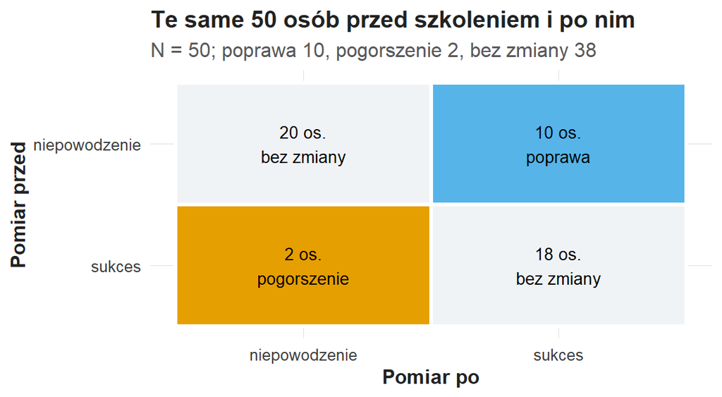

Te same 50 osób przed szkoleniem i po nim. Wiersze: wynik przed; kolumny: wynik po. Przekątna (20 osób z niepowodzeniem i 18 z sukcesem w obu pomiarach) oznacza brak zmiany; 10 osób ma poprawę z niepowodzenia na sukces, a 2 osoby — pogorszenie.

```r
widok <- pokaz_wykres(wykres_przejsc)
print(widok)
```

Przed szkoleniem sukces odniosło 20 osób, po szkoleniu 28, więc różnica proporcji wynosi $8/50=0{,}16$, czyli 16 punktów procentowych. Zmiana kategorii dotyczy 12 osób: 10 poprawiło wynik, a 2 pogorszyły; 38 osób pozostaje w tej samej kategorii.

Test McNemara sprawdza symetrię dwóch kierunków zmiany. W wersji z korektą ciągłości:

$$\chi^2_M=\frac{(|b-c|-1)^2}{b+c}=\frac{(10-2-1)^2}{12}=4{,}08,$$

gdzie $b=10$ i $c=2$ to liczebności par niezgodnych; p = 0,043. Wersja dokładna korzysta z modelu dwumianowego: przy symetrii każda z 12 zmian ma kierunek poprawy z prawdopodobieństwem 0,5, a $p=2\,P(K\ge10)=0{,}039$ dla $K\sim\mathrm{Bin}(12;0{,}5)$.

Proporcja 10/12 opisuje kierunek wśród osób, które zmieniły kategorię; skuteczność po szkoleniu wynosi 28/50 = 56%.

Poprawa łączy działanie szkolenia z efektem powtórzenia i zmianami między pomiarami; przypisanie szkoleniu wymaga grupy kontrolnej. Rozszerzenie uczy rozpoznawać pomiary powtarzane i test dla par.

# Po spotkaniu

Trzy widoki tej samej tabeli — liczebności, procenty w wierszach i procenty w kolumnach — odpowiadają na trzy pytania. Różnica proporcji zachowuje kierunek i jednostkę punktów procentowych, V jest nieujemne, a RR i OR są miarami względnymi o różnym znaczeniu.

Ćwiczenie C08 (Samoocena a wykonanie: korelacja, permutacja i prosta regresja) przechodzi od kategorii do współzmienności wielkości liczbowych: pytanie „czy grupa wiąże się z sukcesem?” zastępuje pytanie „jak wynik deklarowany współzmienia się z obserwowanym czasem?”. Rozróżnienie samoopisu i zachowania pozostaje.

Kontekst merytoryczny: Hargittai (2002) — pomiar umiejętności przez obserwację i logi; van Deursen, Helsper i Eynon (2016) — operacjonalizacja umiejętności internetowych; Vial (2019) — transformacja cyfrowa jako proces szerszy od dostępu do narzędzia. Procedury opisuje dokumentacja funkcji `chisq.test`, `fisher.test` i `prop.test` pakietu stats; znaczenie p — Wasserstein i Lazar (2016). Pełne opisy źródeł zawiera bibliografia na stronie kursu.